# R Notebook

Read in frog data

```r
frogs <- read.csv("~/Desktop/allpit_5yr.csv")
head(frogs)
```

|  | x | swabID | surno | year | PITtag | Nruns | useCorrected | Zoospores | Site_name | date_collected | Julian | SVL | sex | Weight | water_temp |
| --- | --- | --- | --- | --- | --- | --- | --- | --- | --- | --- | --- | --- | --- | --- | --- |
| 1 | 157 | CBS122 | 1 | 2004 | 61783828 | 3 | 1 | 0.2157345 | LittleIndianValley | 7/17/04 | 38185 | 72.0 | F | 42.0 | 17 |
| 2 | 190 | CBS155 | 1 | 2004 | 61783828 | 3 | 0 | 8.8855600 | LittleIndianValley | 7/30/04 | 38198 | 71.7 | F | 51.0 | NA |
| 3 | 283 | CBS242 | 2 | 2004 | 61783828 | 3 | 0 | 0.0000000 | LittleIndianValley | 8/15/04 | 38214 | 73.1 | F | 47.0 | NA |
| 4 | 568 | CBS551 | 4 | 2005 | 61799561 | 1 | 0 | 0.0000000 | LittleIndianValley | 7/15/05 | 38548 | 74.7 | F | 65.0 | NA |
| 5 | 7 | CBS002 | 1 | 2004 | 61825349 | 3 | 0 | 16.0016267 | LittleIndianValley | 6/10/04 | 38148 | 65.5 | M | 34.5 | 14 |
| 6 | 62 | CBS057 | 1 | 2004 | 61825349 | 3 | 0 | 0.0000000 | LittleIndianValley | 7/3/04 | 38171 | 64.9 | M | 38.5 | 23 |

```r
Unicorn<-frogs[frogs$Site_name=="UnicornBasin",]
Mono<-frogs[frogs$Site_name=="MonoPass",]
LIV<-frogs[frogs$Site_name=="LittleIndianValley",]
```

Pretend we want to do a simple analysis comparing the Bd loads between these 3 sites, and look for an effect of snout-to-vent length (SVL) on Bd load. But, General linear models assume that the error (unexplained variance) is normally distributed. Let’s look at the Bd loads at these 3 sites:

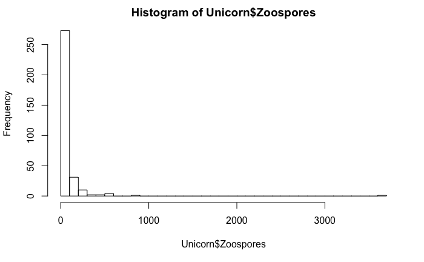

```r
hist(Unicorn$Zoospores,50)
```

```r
mean(Unicorn$Zoospores)
```

```
[1] 60.10219
```

```r
median(Unicorn$Zoospores)
```

```
[1] 7.455776
```

```r
min(Unicorn$Zoospores)
```

```
[1] 0
```

```r
max(Unicorn$Zoospores)
```

```
[1] 3644.688
```

```r
length(Unicorn$Zoospores)
```

```
[1] 324
```

```r
length(Unicorn$Zoospores[Unicorn$Zoospores==0])
```

```
[1] 85
```

```r
length(Unicorn$Zoospores[Unicorn$Zoospores==0])/length(Unicorn$Zoospores)
```

```
[1] 0.2623457
```

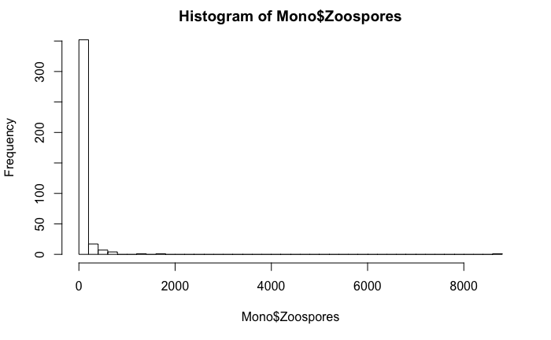

```r
hist(Mono$Zoospores,50)
```

```r
min(Mono$Zoospores)
```

```
[1] 0
```

```r
max(Mono$Zoospores)
```

```
[1] 8654.96
```

```r
length(Mono$Zoospores)
```

```
[1] 383
```

```r
length(Mono$Zoospores[Mono$Zoospores==0])
```

```
[1] 82
```

```r
length(Mono$Zoospores[Mono$Zoospores==0])/length(Mono$Zoospores)
```

```
[1] 0.2140992
```

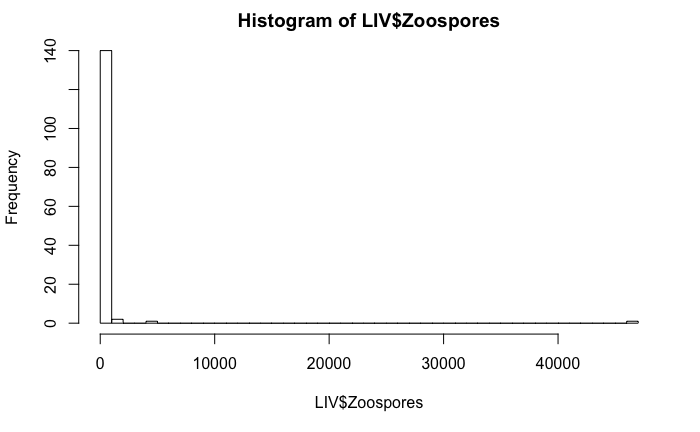

```r
hist(LIV$Zoospores,50)
```

```r
mean(LIV$Zoospores)
```

```
[1] 426.837
```

```r
median(LIV$Zoospores)
```

```
[1] 3.872815
```

```r
min(LIV$Zoospores)
```

```
[1] 0
```

```r
max(LIV$Zoospores)
```

```
[1] 46587.25
```

```r
length(LIV$Zoospores)
```

```
[1] 144
```

```r
length(LIV$Zoospores[LIV$Zoospores==0])
```

```
[1] 56
```

```r
length(LIV$Zoospores[LIV$Zoospores==0])/length(LIV$Zoospores)
```

```
[1] 0.3888889
```

All of these data are clearly not Normally distributed. With so many zeros, we can’t just log transform and add a small number. This just creates a peak at the log of whatever small number we add:

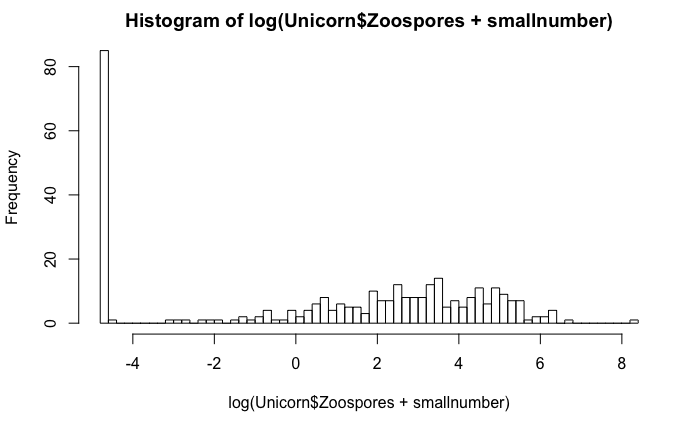

```r
smallnumber=0.01
hist(log(Unicorn$Zoospores+smallnumber),50)
```

# Quick and dirty approach

We could try dividing our analysis into 2 parts, and comparing the fraction infected between the 3 populations, and then comparing the Bd load between the 3 populations. *What cut-off do we use to declare an individual infected?* Zero Zoospores? 1 Zoospore?

We’ll create 2 new variables in frogs:

Infected0 is 1 if Zoospores > 0 (especially if you get multiple 0s)

Infected1 is 1 if Zoospores > 1

```r
frogs$Infected0<-ifelse(frogs$Zoospores>0,1,0)
frogs$Infected1<-ifelse(frogs$Zoospores>1,1,0)
```

Logistic regression to compare Bd prevalence at the 3 sites: First for Infected0

```r
prevmod0 <- glm(Infected0 ~ Site_name+SVL, data = frogs, family = "binomial")
summary(prevmod0)
```

```
Call:
glm(formula = Infected0 ~ Site_name + SVL, family = "binomial",
    data = frogs)

Deviance Residuals:
    Min       1Q   Median       3Q      Max
-1.8213  -1.3249   0.6978   0.7523   1.0443

Coefficients:
                       Estimate Std. Error z value Pr(>|z|)
(Intercept)           -0.120109   0.855601  -0.140 0.888360
Site_nameMonoPass      0.854330   0.221590   3.855 0.000116 ***
Site_nameUnicornBasin  0.686665   0.236025   2.909 0.003623 **
SVL                    0.009434   0.012933   0.729 0.465742
---
Signif. codes:  0 ‘***’ 0.001 ‘**’ 0.01 ‘*’ 0.05 ‘.’ 0.1 ‘ ’ 1

(Dispersion parameter for binomial family taken to be 1)

    Null deviance: 929.93  on 821  degrees of freedom
Residual deviance: 915.26  on 818  degrees of freedom
  (29 observations deleted due to missingness)
AIC: 923.26

Number of Fisher Scoring iterations: 4
```

Logistic regression to compare Bd prevalence at the 3 sites: Then for Infected1

```r
prevmod1 <- glm(Infected1 ~ Site_name+SVL, data = frogs, family = "binomial")
summary(prevmod1)
```

```
Call:
glm(formula = Infected1 ~ Site_name + SVL, family = "binomial",
    data = frogs)

Deviance Residuals:
    Min       1Q   Median       3Q      Max
-1.6998  -1.4131   0.8283   0.8844   1.2583

Coefficients:
                      Estimate Std. Error z value Pr(>|z|)
(Intercept)           -1.24792    0.80503  -1.550  0.12111
Site_nameMonoPass      0.71176    0.21116   3.371  0.00075 ***
Site_nameUnicornBasin  0.67732    0.22648   2.991  0.00278 **
SVL                    0.02264    0.01214   1.865  0.06223 .
---
Signif. codes:  0 ‘***’ 0.001 ‘**’ 0.01 ‘*’ 0.05 ‘.’ 0.1 ‘ ’ 1

(Dispersion parameter for binomial family taken to be 1)

    Null deviance: 1045  on 821  degrees of freedom
Residual deviance: 1032  on 818  degrees of freedom
  (29 observations deleted due to missingness)
AIC: 1040

Number of Fisher Scoring iterations: 4
```

frogload0 is a dataset with only Bd-positive frogs, using the 0 zoospore cut-off.

frogload1 is a dataset with only Bd-positive frogs, using the 1 zoospore cut-off.

```r
frogload0<-frogs[frogs$Zoospores>0,]
frogload1<-frogs[frogs$Zoospores>1,]
```

Create new variable that is log of zoospores in each of these datasets:

```r
# dont have to add values since they've all be transformed to be greater than 0
frogload0$logZoospores = log(frogload0$Zoospores)
frogload1$logZoospores = log(frogload1$Zoospores)
```

Use lm to compare Bd loads between sites for only the infected frogs. First using the 0 zoospore cut-off

```r
loadmod0<-lm(logZoospores ~ Site_name+SVL, data = frogload0)
summary(loadmod0)
```

```
Call:
lm(formula = logZoospores ~ Site_name + SVL, data = frogload0)

Residuals:
    Min      1Q  Median      3Q     Max
-9.0684 -1.1792  0.2672  1.5925  7.6517

Coefficients:
                      Estimate Std. Error t value Pr(>|t|)
(Intercept)            0.08833    1.02071   0.087  0.93106
Site_nameMonoPass     -0.33568    0.28120  -1.194  0.23305
Site_nameUnicornBasin -0.11918    0.30194  -0.395  0.69318
SVL                    0.04807    0.01531   3.139  0.00178 **
---
Signif. codes:  0 ‘***’ 0.001 ‘**’ 0.01 ‘*’ 0.05 ‘.’ 0.1 ‘ ’ 1

Residual standard error: 2.252 on 610 degrees of freedom
  (14 observations deleted due to missingness)
Multiple R-squared:  0.02091,   Adjusted R-squared:  0.01609
F-statistic: 4.341 on 3 and 610 DF,  p-value: 0.004863
```

Then using the 1 Zoospore cut off:

```r
# cut off 1
# SVL effect goes away
loadmod1<-lm(logZoospores ~ Site_name+SVL, data = frogload1)
summary(loadmod1)
```

```
Call:
lm(formula = logZoospores ~ Site_name + SVL, data = frogload1)

Residuals:
    Min      1Q  Median      3Q     Max
-3.3308 -1.2285 -0.0542  1.2250  7.0665

Coefficients:
                      Estimate Std. Error t value Pr(>|t|)
(Intercept)            2.47233    0.81561   3.031  0.00255 **
Site_nameMonoPass     -0.36112    0.21909  -1.648  0.09987 .
Site_nameUnicornBasin -0.36651    0.23573  -1.555  0.12058
SVL                    0.01933    0.01223   1.581  0.11439
---
Signif. codes:  0 ‘***’ 0.001 ‘**’ 0.01 ‘*’ 0.05 ‘.’ 0.1 ‘ ’ 1

Residual standard error: 1.658 on 545 degrees of freedom
  (14 observations deleted due to missingness)
Multiple R-squared:  0.0137,    Adjusted R-squared:  0.008272
F-statistic: 2.524 on 3 and 545 DF,  p-value: 0.0569
```

Let’s try the Zero-inflated models. The models that are based on Poisson and Negative Binomial distributions are expecting count data. That is, they are expecting integer values only. We still need to decide what to do for the values of zoospores between 0 and 1.  
Are these individuals infected or uninfected? Should we include these individuals in the 0 category, or in the 1 category????

Let’s try both options.

```r
frogs$Zoosp_round_down <- floor(frogs$Zoospores)
frogs$Zoosp_round_up <- ceiling(frogs$Zoospores)
```

## ZIP and ZINB models

```r
install.packages("pscl")
```

```
Error in install.packages : Updating loaded packages
```

```r
install.packages("lmtest")
```

```
Error in install.packages : Updating loaded packages
```

```r
library(pscl)
library(lmtest)
```

Zero inflated Poisson:

2 type of 0s: good and bad zeroes

```r
# posi: variance = mean
f1down <- formula(Zoosp_round_down ~ Site_name + SVL | Site_name + SVL) # what explains the load that's not 0 # | explantory variables if something is infected or not
ZIP_round_down <- zeroinfl(f1down, dist = "poisson", link = "logit", data = frogs)
summary(ZIP_round_down)
```

```
Call:
zeroinfl(formula = f1down, data = frogs, dist = "poisson", link = "logit")

Pearson residuals:
     Min       1Q   Median       3Q      Max
 -1.7601  -1.4078  -1.1939  -0.6832 165.0332

Count model coefficients (poisson with log link):
                        Estimate Std. Error z value Pr(>|z|)
(Intercept)            7.8408953  0.0262280  298.95   <2e-16 ***
Site_nameMonoPass     -1.9648044  0.0070019 -280.61   <2e-16 ***
Site_nameUnicornBasin -2.3248846  0.0087092 -266.95   <2e-16 ***
SVL                   -0.0178537  0.0004077  -43.79   <2e-16 ***

Zero-inflation model coefficients (binomial with logit link):
                      Estimate Std. Error z value Pr(>|z|)
(Intercept)            1.24792    0.80503   1.550 0.121106
Site_nameMonoPass     -0.71176    0.21115  -3.371 0.000749 ***
Site_nameUnicornBasin -0.67732    0.22646  -2.991 0.002782 **
SVL                   -0.02264    0.01215  -1.864 0.062273 .
---
Signif. codes:  0 '***' 0.001 '**' 0.01 '*' 0.05 '.' 0.1 ' ' 1

Number of iterations in BFGS optimization: 1
Log-likelihood: -2.686e+05 on 8 Df
```

Zero inflated Negative Binomial:

```r
f1down <- formula(Zoosp_round_down ~ Site_name + SVL | Site_name )
ZINB_round_down <- zeroinfl(f1down, dist = "negbin", link = "logit", data = frogs) # changed distribution
summary(ZINB_round_down)
```

```
Call:
zeroinfl(formula = f1down, data = frogs, dist = "negbin", link = "logit")

Pearson residuals:
    Min      1Q  Median      3Q     Max
-0.4341 -0.4337 -0.3552 -0.2098 42.9833

Count model coefficients (negbin with log link):
                      Estimate Std. Error z value Pr(>|z|)
(Intercept)            5.11652    1.08139   4.731 2.23e-06 ***
Site_nameMonoPass     -2.02994    0.26883  -7.551 4.32e-14 ***
Site_nameUnicornBasin -2.27698    0.28344  -8.033 9.49e-16 ***
SVL                    0.02140    0.01694   1.263    0.206
Log(theta)            -1.66717    0.05179 -32.193  < 2e-16 ***

Zero-inflation model coefficients (binomial with logit link):
                      Estimate Std. Error z value Pr(>|z|)
(Intercept)            -0.8740     0.2721  -3.212  0.00132 **
Site_nameMonoPass     -15.9587   936.0222  -0.017  0.98640
Site_nameUnicornBasin -11.9093   155.7185  -0.076  0.93904
---
Signif. codes:  0 '***' 0.001 '**' 0.01 '*' 0.05 '.' 0.1 ' ' 1

Theta = 0.1888
Number of iterations in BFGS optimization: 104
Log-likelihood: -3443 on 8 Df
```

Likelihood ratio test to compare ZIP and ZINB

```r
# test the two models
lrtest(ZIP_round_down,ZINB_round_down)
```

```
Likelihood ratio test

Model 1: Zoosp_round_down ~ Site_name + SVL | Site_name + SVL
Model 2: Zoosp_round_down ~ Site_name + SVL | Site_name
  #Df  LogLik Df  Chisq Pr(>Chisq)
1   8 -268589
2   8   -3443  0 530293  < 2.2e-16 ***
---
Signif. codes:  0 ‘***’ 0.001 ‘**’ 0.01 ‘*’ 0.05 ‘.’ 0.1 ‘ ’ 1
```

Overwhelming evidence to go with ZINB, rather than ZIP

# ZIP and ZINB on zoospores_round_up

Rounding data up

Zero inflated Poisson:

```r
f1up <- formula(Zoosp_round_up ~ Site_name + SVL | Site_name)
ZIP_round_up <- zeroinfl(f1up, dist = "poisson", link = "logit", data = frogs)
summary(ZIP_round_up)
```

```
Call:
zeroinfl(formula = f1up, data = frogs, dist = "poisson", link = "logit")

Pearson residuals:
     Min       1Q   Median       3Q      Max
 -1.8918  -1.7052  -1.3315  -0.8025 200.2824

Count model coefficients (poisson with log link):
                        Estimate Std. Error z value Pr(>|z|)
(Intercept)            7.4805061  0.0257749  290.22   <2e-16 ***
Site_nameMonoPass     -1.9551182  0.0069927 -279.59   <2e-16 ***
Site_nameUnicornBasin -2.2835744  0.0086712 -263.35   <2e-16 ***
SVL                   -0.0139676  0.0003998  -34.94   <2e-16 ***

Zero-inflation model coefficients (binomial with logit link):
                      Estimate Std. Error z value Pr(>|z|)
(Intercept)            -0.4914     0.1761  -2.791 0.005251 **
Site_nameMonoPass      -0.8203     0.2165  -3.789 0.000151 ***
Site_nameUnicornBasin  -0.6246     0.2201  -2.837 0.004551 **
---
Signif. codes:  0 '***' 0.001 '**' 0.01 '*' 0.05 '.' 0.1 ' ' 1

Number of iterations in BFGS optimization: 1
Log-likelihood: -2.803e+05 on 7 Df
```

Zero inflated Negative Binomial:

```r
f1up <- formula(Zoosp_round_up ~ Site_name + SVL | Site_name)
ZINB_round_up <- zeroinfl(f1up, dist = "negbin", link = "logit", data = frogs)
summary(ZINB_round_up)
```

```
Call:
zeroinfl(formula = f1up, data = frogs, dist = "negbin", link = "logit")

Pearson residuals:
   Min     1Q Median     3Q    Max
     0      0      0      0      0

Count model coefficients (negbin with log link):
                      Estimate Std. Error z value Pr(>|z|)
(Intercept)            -10.171         NA      NA       NA
Site_nameMonoPass       -2.138         NA      NA       NA
Site_nameUnicornBasin   -2.391         NA      NA       NA
SVL                      8.960         NA      NA       NA
Log(theta)             -16.764         NA      NA       NA

Zero-inflation model coefficients (binomial with logit link):
                      Estimate Std. Error z value Pr(>|z|)
(Intercept)            -0.7355         NA      NA       NA
Site_nameMonoPass      -0.9211         NA      NA       NA
Site_nameUnicornBasin  -0.7162         NA      NA       NA

Theta = 0
Number of iterations in BFGS optimization: 2
Log-likelihood: -1.229e+04 on 8 Df
```

```r
lrtest(ZIP_round_down,ZINB_round_down)
```

```
Likelihood ratio test

Model 1: Zoosp_round_down ~ Site_name + SVL | Site_name + SVL
Model 2: Zoosp_round_down ~ Site_name + SVL | Site_name
  #Df  LogLik Df  Chisq Pr(>Chisq)
1   8 -268589
2   8   -3443  0 530293  < 2.2e-16 ***
---
Signif. codes:  0 ‘***’ 0.001 ‘**’ 0.01 ‘*’ 0.05 ‘.’ 0.1 ‘ ’ 1
```

### Zero Adjusted Poisson and Negative Binomial (hurdle models)

Now try hurdle models

# ZAP and ZANB on Zoosp_round_down

```r
H1downA <- hurdle(f1down, dist = "poisson", link = "logit",data = frogs)
H1downB <- hurdle(f1down, dist = "negbin", link = "logit",data = frogs)
lrtest(H1downA,H1downB)
```

```
Likelihood ratio test

Model 1: Zoosp_round_down ~ Site_name + SVL | Site_name
Model 2: Zoosp_round_down ~ Site_name + SVL | Site_name
  #Df  LogLik Df  Chisq Pr(>Chisq)
1   7 -268591
2   8   -3439  1 530303  < 2.2e-16 ***
---
Signif. codes:  0 ‘***’ 0.001 ‘**’ 0.01 ‘*’ 0.05 ‘.’ 0.1 ‘ ’ 1
```

Definitely need to use Negative Binomial version

```r
summary(H1downB)
```

```
Call:
hurdle(formula = f1down, data = frogs, dist = "negbin", link = "logit")

Pearson residuals:
    Min      1Q  Median      3Q     Max
-0.4103 -0.4026 -0.3210 -0.1892 40.9892

Count model coefficients (truncated negbin with log link):
                      Estimate Std. Error z value Pr(>|z|)
(Intercept)            5.49143    1.24471   4.412 1.03e-05 ***
Site_nameMonoPass     -2.10204    0.30770  -6.831 8.41e-12 ***
Site_nameUnicornBasin -2.39314    0.32393  -7.388 1.49e-13 ***
SVL                    0.01178    0.01934   0.609    0.543
Log(theta)            -2.14067    0.22216  -9.636  < 2e-16 ***
Zero hurdle model coefficients (binomial with logit link):
                      Estimate Std. Error z value Pr(>|z|)
(Intercept)             0.2199     0.1719   1.279  0.20091
Site_nameMonoPass       0.6287     0.2054   3.061  0.00221 **
Site_nameUnicornBasin   0.5274     0.2108   2.502  0.01236 *
---
Signif. codes:  0 '***' 0.001 '**' 0.01 '*' 0.05 '.' 0.1 ' ' 1

Theta: count = 0.1176
Number of iterations in BFGS optimization: 22
Log-likelihood: -3439 on 8 Df
```

# ZAP and ZANB on Zoosp_round_up

```r
H1upA <- hurdle(f1up, dist = "poisson", link = "logit",data = frogs)
H1upB <- hurdle(f1up, dist = "negbin", link = "logit",data = frogs)
lrtest(H1upA,H1upB)
```

```
Likelihood ratio test

Model 1: Zoosp_round_up ~ Site_name + SVL | Site_name
Model 2: Zoosp_round_up ~ Site_name + SVL | Site_name
  #Df  LogLik Df  Chisq Pr(>Chisq)
1   7 -280262
2   8   -3574  1 553375  < 2.2e-16 ***
---
Signif. codes:  0 ‘***’ 0.001 ‘**’ 0.01 ‘*’ 0.05 ‘.’ 0.1 ‘ ’ 1
```

Definitely need to use Negative Binomial version

```r
summary(H1upB)
```

```
Call:
hurdle(formula = f1up, data = frogs, dist = "negbin", link = "logit")

Pearson residuals:
    Min      1Q  Median      3Q     Max
-0.4056 -0.3881 -0.3044 -0.1853 38.9910

Count model coefficients (truncated negbin with log link):
                      Estimate Std. Error z value Pr(>|z|)
(Intercept)            4.04667    1.44556   2.799  0.00512 **
Site_nameMonoPass     -2.16477    0.33869  -6.392 1.64e-10 ***
Site_nameUnicornBasin -2.40323    0.35742  -6.724 1.77e-11 ***
SVL                    0.02243    0.02155   1.041  0.29797
Log(theta)            -3.09852    0.52186  -5.937 2.89e-09 ***
Zero hurdle model coefficients (binomial with logit link):
                      Estimate Std. Error z value Pr(>|z|)
(Intercept)             0.4914     0.1761   2.791 0.005251 **
Site_nameMonoPass       0.8203     0.2165   3.789 0.000151 ***
Site_nameUnicornBasin   0.6246     0.2201   2.837 0.004551 **
---
Signif. codes:  0 '***' 0.001 '**' 0.01 '*' 0.05 '.' 0.1 ' ' 1

Theta: count = 0.0451
Number of iterations in BFGS optimization: 23
Log-likelihood: -3574 on 8 Df
```